# An Examination of Transformations of Skewed Datasets

#### *CIE 600: Environmental Data Analysis: Scripting Assignment 1*

#### *Feb 7, 2017*

## Initial data

We are starting with two simple datasets. “posskew” has positively skewed data and “negskew” has negatively skewed data. The positive skew data is a hypothetical counting of the number of times a week a small child cries at Disneyland. The negative skew data is a hypothetical counting of the number of times a week a mascot steps on a child at Disneyland. The two are mutually exclusive.

```r
posskew = c(1, 2, 2, 3,3,3, 4,4,4,4, 5,5,5,5,5, 6,6,6,6,6,6,6,6,6,6,6,6,6, 7,7,7,7,7,7,7, 8,8,8,8,8,8,8, 9, 9, 9,9,9, 10,10, 10,10, 11,11,11, 11, 12 ,12, 13,13,13,13,13,13, 14,14, 17,21,23, 26, 17, 32, 36, 48, 38, 40, 47, 51, 52)

posmean = mean(posskew) #calculating the mean of positive skew data
posmed = median(posskew) #calculating the median of positive skew data

negskew = c(1,2,3,4,4,5,6,6,7,7,7,8,9,10, 13, 14, 17, 20, 20 ,21, 21, 23, 23, 24, 24, 24, 24, 27, 27, 27, 27, 28, 28, 28, 29 ,29, 29, 29, 30,30,30,30,30,31,31,31,31,31,31,31,32,32,32,32,32,32,32, 32, 33,33,33,33,33,33,33, 34,34,34,34,34,34,35,35,35,35,35,35,37,38,39)

negmean = mean(negskew) #calculating the mean of negative skew data
negmed = median(negskew) #calculating the median of negative skew data
```

Next we plot the data sets on histograms with the mean and median values

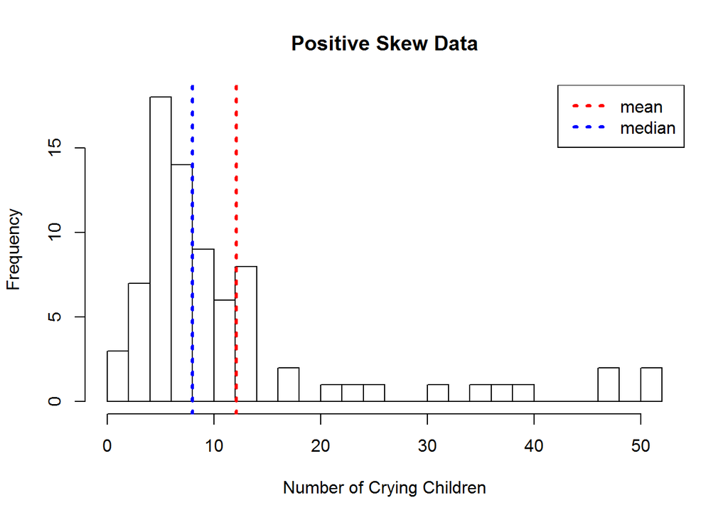

```r
#plotting positive skew data
hist(posskew, breaks = 21, xlab = "Number of Crying Children", ylab = "Frequency", main = "Positive Skew Data")
abline(v=posmean, col='red', lty=3, lwd=3) #add a vertical line for the mean
abline(v=posmed, col='blue', lty=3, lwd=3) #add a vertical line for the mean
legend('topright', legend=c("mean", "median"), lty=rep(3,4), lwd=rep(3,4), col=c("red","blue"))
```

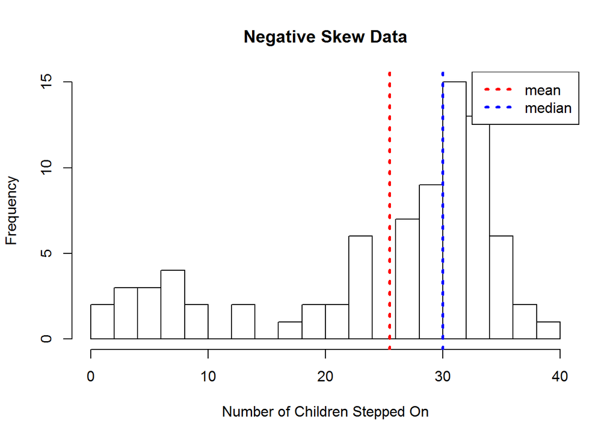

```r
#plotting negative skew data
hist(negskew, breaks = 21, xlab = "Number of Children Stepped On", ylab = "Frequency", main = "Negative Skew Data")
abline(v=negmean, col='red', lty=3, lwd=3) #add a vertical line for the mean
abline(v=negmed, col='blue', lty=3, lwd=3) #add a vertical line for the mean
legend('topright', legend=c("mean", "median"), lty=rep(3,4), lwd=rep(3,4), col=c("red","blue"))
```

You can see here that for the positive skew data the mean is greater than the median and for the negative skew the median is greater tan the mean.

## Initial data transformed into log scale

Now we will take the initial datasets and transform them into a log scale

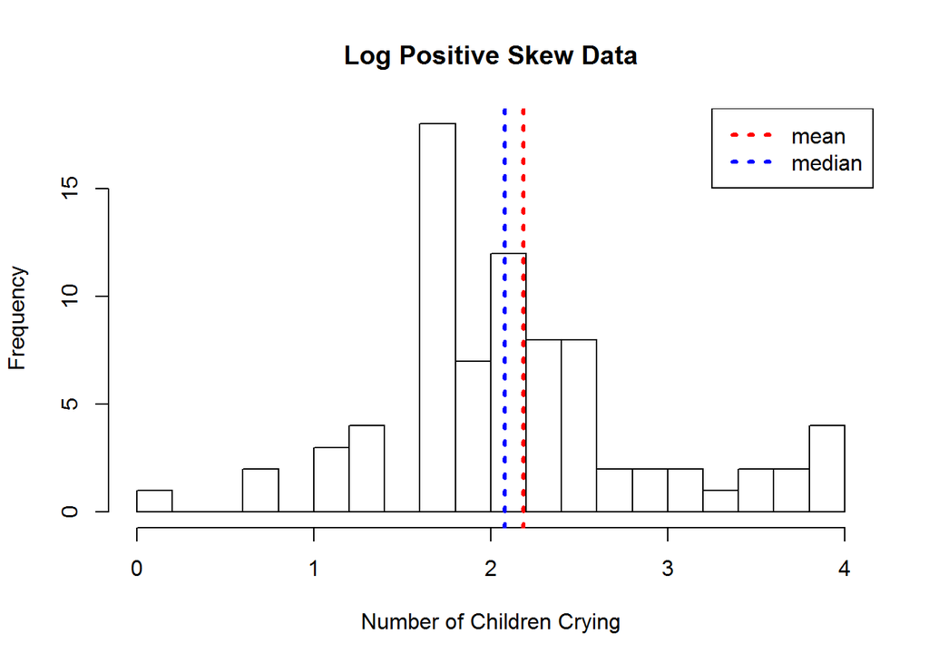

```r
#Transform positive data LOG

#First we transform initial datasets into log
logpos = log(posskew)
plogmean = mean(logpos)
plogmed = median(logpos)
#make histogram of transformed data
hist(logpos, breaks = 15, xlab = "Number of Children Crying", ylab = "Frequency", main = "Log Positive Skew Data")
abline(v=plogmean, col='red', lty=3, lwd=3) #add a vertical line for the mean
abline(v=plogmed, col='blue', lty=3, lwd=3) #add a vertical line for the mean
legend('topright', legend=c("mean", "median"), lty=rep(3,4), lwd=rep(3,4), col=c("red","blue"))
```

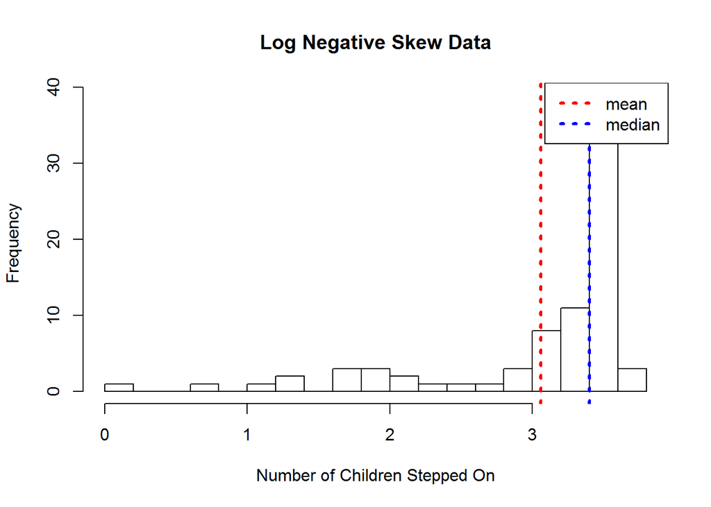

```r
#Transform negative data LOG
#transform negative data to log
logneg = log(negskew)
nlogmean = mean(logneg)
nlogmed = median(logneg)
#make histogram of transformed data
hist(logneg, breaks = 15, xlab = "Number of Children Stepped On", ylab = "Frequency", main = "Log Negative Skew Data")
abline(v=nlogmean, col='red', lty=3, lwd=3) #add a vertical line for the mean
abline(v=nlogmed, col='blue', lty=3, lwd=3) #add a vertical line for the mean
legend('topright', legend=c("mean", "median"), lty=rep(3,4), lwd=rep(3,4), col=c("red","blue"))
```

As can be seen in the histograms, the positive skew data follows a normal distribution but the mean stil stays greater then the median. The negative skewed data however is not normalized and shifts the mean and median towards more positive ranges. The negative skew mean remains less than the median.

## Initial data transformed with box-cox

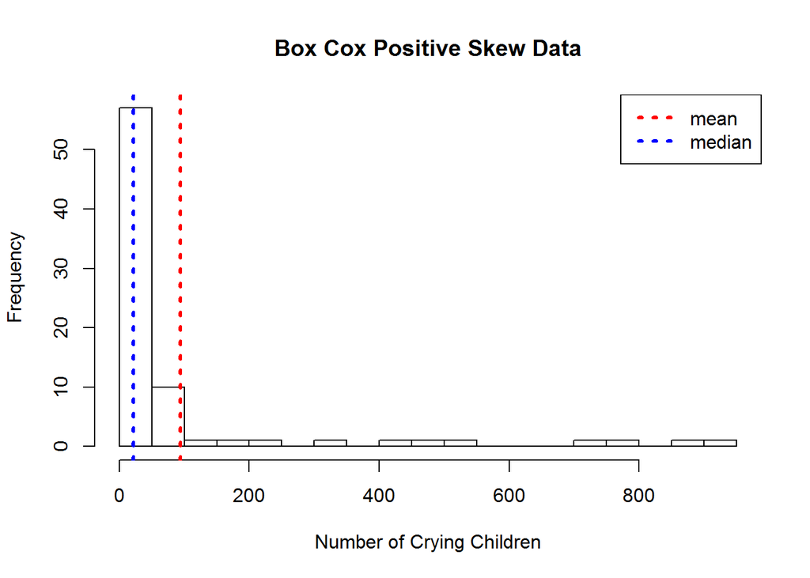

```r
#first declare lambda L equal to 3
L = 3

#transform positive skew data
bcpos = (posskew^(L-1))/L
pbcmean = mean(bcpos)
pbcmed = median(bcpos)
#make histogram
hist(bcpos, breaks = 15, xlab = "Number of Crying Children", ylab = "Frequency", main = "Box Cox Positive Skew Data")
abline(v=pbcmean, col='red', lty=3, lwd=3) #add a vertical line for the mean
abline(v=pbcmed, col='blue', lty=3, lwd=3) #add a vertical line for the mean
legend('topright', legend=c("mean", "median"), lty=rep(3,4), lwd=rep(3,4), col=c("red","blue"))
```

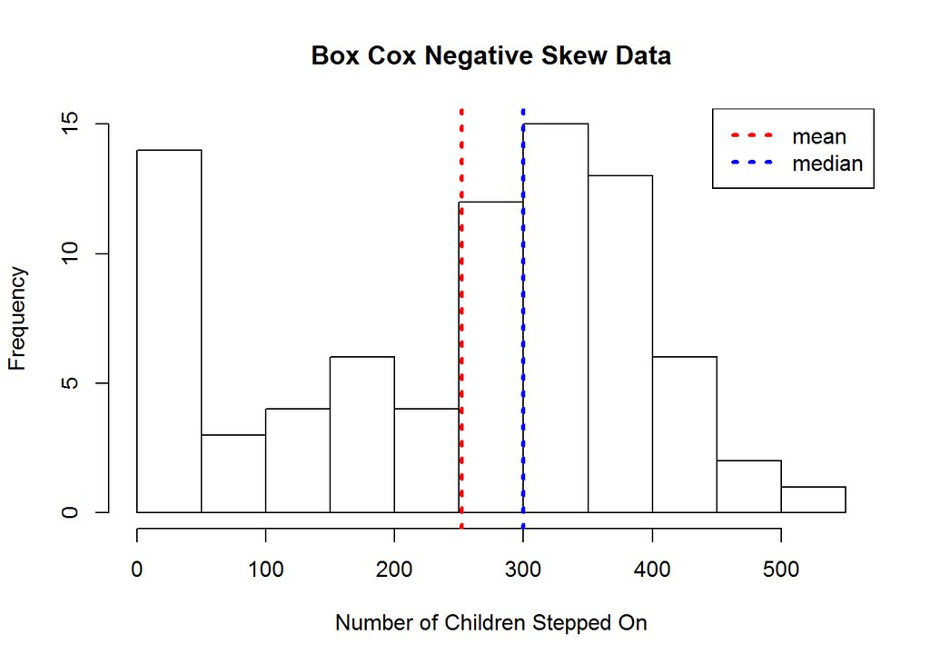

```r
#transform negative skew data
bcneg = (negskew^(L-1))/L
nbcmean = mean(bcneg)
nbcmed = median(bcneg)
#make histogram
hist(bcneg, breaks = 15, xlab = "Number of Children Stepped On", ylab = "Frequency", main = "Box Cox Negative Skew Data")
abline(v=nbcmean, col='red', lty=3, lwd=3) #add a vertical line for the mean
abline(v=nbcmed, col='blue', lty=3, lwd=3) #add a vertical line for the mean
legend('topright', legend=c("mean", "median"), lty=rep(3,4), lwd=rep(3,4), col=c("red","blue"))
```

The positive skew data shifted toward the left with most transformed values being less than 50. The mean remains greater than the median. The negative skew data is more evenly distributed than before. The mean remains less than the median.

## Initial data transformed with standardized anomalies

Next we transform the data with standardized anomalies. The mean is subtracted from each value and then divided by the standard deviation.

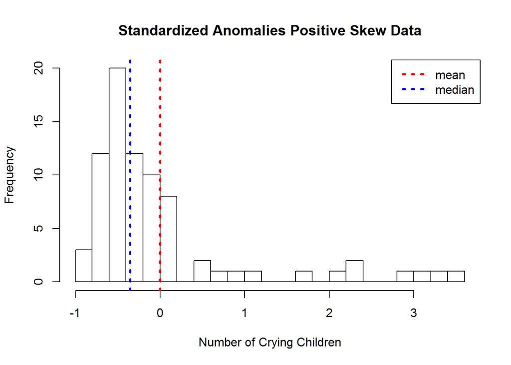

```r
#Transform positive skew data
#calculate the standard deviation of positive skew data
std = sd(posskew)
#calculate standardized anomalies for positive skew
z = (posskew - posmean)/std
pzmean = mean(z)
pzmed = median(z)
#make histogram
hist(z, breaks = 21, xlab = "Number of Crying Children", ylab = "Frequency", main = "Standardized Anomalies Positive Skew Data")
abline(v=pzmean, col='red', lty=3, lwd=3) #add a vertical line for the mean
abline(v=pzmed, col='blue', lty=3, lwd=3) #add a vertical line for the mean
legend('topright', legend=c("mean", "median"), lty=rep(3,4), lwd=rep(3,4), col=c("red","blue"))
```

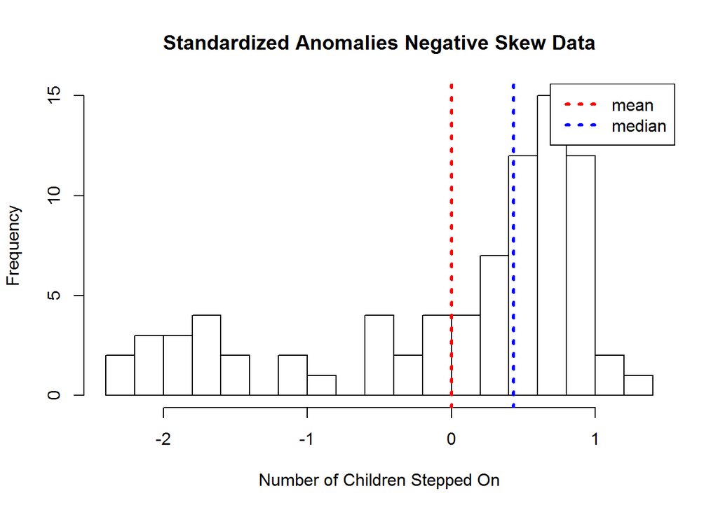

```r
#Transform negative skew data
#calculate the standard deviation of negative skew data
std = sd(negskew)
#calculate standardized anomalies for negative skew
z = (negskew - negmean)/std
nzmean = mean(z)
nzmed = median(z)
#Make histogram
hist(z, breaks = 21, xlab = "Number of Children Stepped On", ylab = "Frequency", main = "Standardized Anomalies Negative Skew Data")
abline(v=nzmean, col='red', lty=3, lwd=3) #add a vertical line for the mean
abline(v=nzmed, col='blue', lty=3, lwd=3) #add a vertical line for the mean
legend('topright', legend=c("mean", "median"), lty=rep(3,4), lwd=rep(3,4), col=c("red","blue"))
```

For both the positive and negative skew data the distribution did not change, only the scale. Both shifted to include negative values. These values show how many standard deviations away from the mean a value is.

## Initial data transformed with an exponent

Next we transform the data with an exponent by squaring the data values.

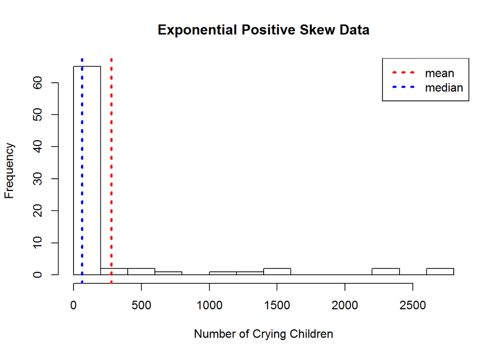

```r
#Transform positive skew data
#take value squared
epos = posskew^2
pemean = mean(epos)
pemed = median(epos)
#Make histogram
hist(epos, breaks = 15, xlab = "Number of Crying Children", ylab = "Frequency", main = "Exponential Positive Skew Data")
abline(v=pemean, col='red', lty=3, lwd=3) #add a vertical line for the mean
abline(v=pemed, col='blue', lty=3, lwd=3) #add a vertical line for the mean
legend('topright', legend=c("mean", "median"), lty=rep(3,4), lwd=rep(3,4), col=c("red","blue"))
```

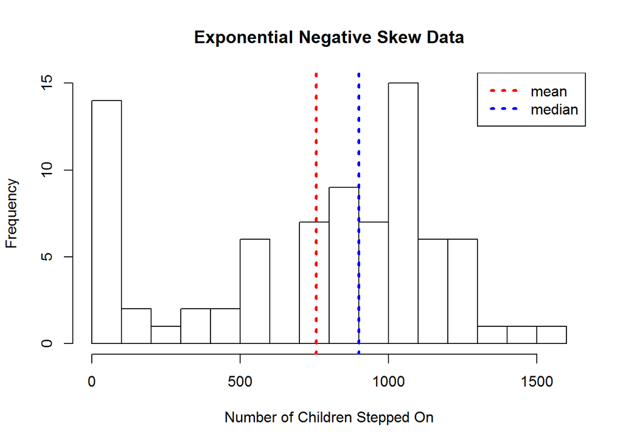

```r
#Transform negative skew data
#take value squared
eneg = negskew^2
nemean = mean(eneg)
nemed = median(eneg)
#make histogram
hist(eneg, breaks = 15, xlab = "Number of Children Stepped On", ylab = "Frequency", main = "Exponential Negative Skew Data")
abline(v=nemean, col='red', lty=3, lwd=3) #add a vertical line for the mean
abline(v=nemed, col='blue', lty=3, lwd=3) #add a vertical line for the mean
legend('topright', legend=c("mean", "median"), lty=rep(3,4), lwd=rep(3,4), col=c("red","blue"))
```

The positive skew data once again shifts to the left with most transformed data falling in the smallest bin range. The negative skew data was more evenly distributed. Both once again retained mean and median arrangement.

## Summary

Okay now we can put it all together.

[figure not shown]

```r
par(mfrow=c(5,2), mar=c(2,2,2,2)) #setting up a multi-panel figure

#Original Data
  #postive
hist(posskew, breaks = 21, xlab = "Number of Crying Children", ylab = "Frequency", main = "Positive Skew Data")
abline(v=posmean, col='red', lty=3, lwd=3) #add a vertical line for the mean
abline(v=posmed, col='blue', lty=3, lwd=3) #add a vertical line for the mean
legend('topright', legend=c("mean", "median"), lty=rep(3,4), lwd=rep(3,4), col=c("red","blue"))
  #negative
hist(negskew, breaks = 21, xlab = "Number of Children Stepped On", ylab = "Frequency", main = "Negative Skew Data")
abline(v=negmean, col='red', lty=3, lwd=3) #add a vertical line for the mean
abline(v=negmed, col='blue', lty=3, lwd=3) #add a vertical line for the mean
#legend('topright', legend=c("mean", "median"), lty=rep(3,4), lwd=rep(3,4), col=c("red","blue"))

#Log Scale
  #postive
hist(logpos, breaks = 15, xlab = "Number of Children Crying", ylab = "Frequency", main = "Log Positive Skew Data")
abline(v=plogmean, col='red', lty=3, lwd=3) #add a vertical line for the mean
abline(v=plogmed, col='blue', lty=3, lwd=3) #add a vertical line for the mean
#legend('topright', legend=c("mean", "median"), lty=rep(3,4), lwd=rep(3,4), col=c("red","blue"))
  #negative
hist(logneg, breaks = 15, xlab = "Number of Children Stepped On", ylab = "Frequency", main = "Log Negative Skew Data")
abline(v=nlogmean, col='red', lty=3, lwd=3) #add a vertical line for the mean
abline(v=nlogmed, col='blue', lty=3, lwd=3) #add a vertical line for the mean
#legend('topright', legend=c("mean", "median"), lty=rep(3,4), lwd=rep(3,4), col=c("red","blue"))

#Box-Cox
  #postive
hist(bcpos, breaks = 15, xlab = "Number of Crying Children", ylab = "Frequency", main = "Box Cox Positive Skew Data")
abline(v=pbcmean, col='red', lty=3, lwd=3) #add a vertical line for the mean
abline(v=pbcmed, col='blue', lty=3, lwd=3) #add a vertical line for the mean
#legend('topright', legend=c("mean", "median"), lty=rep(3,4), lwd=rep(3,4), col=c("red","blue"))
  #negative
hist(bcneg, breaks = 15, xlab = "Number of Children Stepped On", ylab = "Frequency", main = "Box Cox Negative Skew Data")
abline(v=nbcmean, col='red', lty=3, lwd=3) #add a vertical line for the mean
abline(v=nbcmed, col='blue', lty=3, lwd=3) #add a vertical line for the mean
#legend('topright', legend=c("mean", "median"), lty=rep(3,4), lwd=rep(3,4), col=c("red","blue"))

#Standardized Anomalies
  #postive
hist(z, breaks = 21, xlab = "Number of Crying Children", ylab = "Frequency", main = "Standardized Anomalies Positive Skew Data")
abline(v=pzmean, col='red', lty=3, lwd=3) #add a vertical line for the mean
abline(v=pzmed, col='blue', lty=3, lwd=3) #add a vertical line for the mean
#legend('topright', legend=c("mean", "median"), lty=rep(3,4), lwd=rep(3,4), col=c("red","blue"))
  #negative
hist(z, breaks = 21, xlab = "Number of Children Stepped On", ylab = "Frequency", main = "Standardized Anomalies Negative Skew Data")
abline(v=nzmean, col='red', lty=3, lwd=3) #add a vertical line for the mean
abline(v=nzmed, col='blue', lty=3, lwd=3) #add a vertical line for the mean
#legend('topright', legend=c("mean", "median"), lty=rep(3,4), lwd=rep(3,4), col=c("red","blue"))

#Standardized anomalies
  #positive
hist(epos, breaks = 15, xlab = "Number of Crying Children", ylab = "Frequency", main = "Exponential Positive Skew Data")
abline(v=pemean, col='red', lty=3, lwd=3) #add a vertical line for the mean
abline(v=pemed, col='blue', lty=3, lwd=3) #add a vertical line for the mean
#legend('topright', legend=c("mean", "median"), lty=rep(3,4), lwd=rep(3,4), col=c("red","blue"))
  #negative
hist(eneg, breaks = 15, xlab = "Number of Children Stepped On", ylab = "Frequency", main = "Exponential Negative Skew Data")
abline(v=nemean, col='red', lty=3, lwd=3) #add a vertical line for the mean
abline(v=nemed, col='blue', lty=3, lwd=3) #add a vertical line for the mean
```

```r
#legend('topright', legend=c("mean", "median"), lty=rep(3,4), lwd=rep(3,4), col=c("red","blue"))
```

[output not shown]